# Frequentist vs. Bayesian inference

# Probability intervals

- PMF $P(\theta)$ or PDF $f(\theta)$
- $p$-probability interval for $\theta$
  - An interval $[a,b]$ with $P(a \leq \theta \leq b) = p$
- Credible intervals
- Not the same as confidence intervals

# Probability intervals

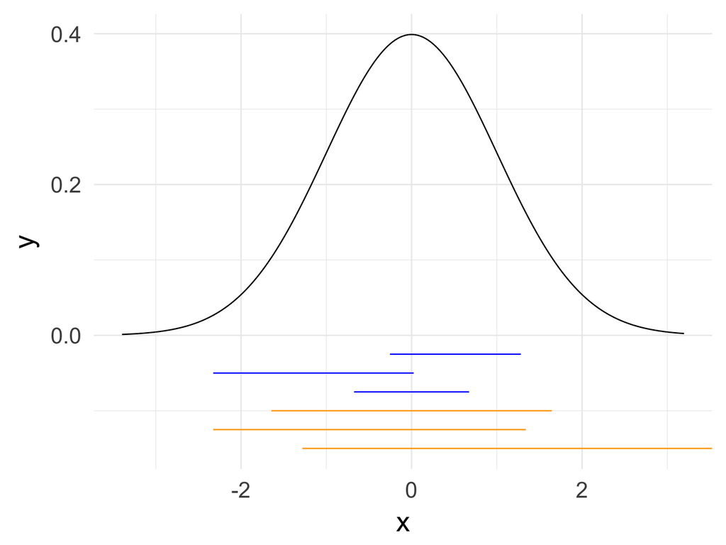

# Probability intervals

> I think $\theta$ is between 0.45 and 0.65 with 50% probability.

> I think $\theta$ follows a $\text{Beta}(8, 6)$ distribution.

# Frequentist inference

$$P(H|D) = \frac{P(D | H) \cdot P(H)}{P(D)}$$

- When the prior is known
- When the prior is not known
  - Bayesians
  - Frequentists

    $$L(H; D) = P(D|H)$$
- What is the meaning of probability?
- Bayesians - probability of hypotheses and data
- Frequentists - probability of data given a hypothesis

# Null hypothesis testing

- Assume an hypothesis is true
- Observed data sampled from that distribution
- Probability of observing data given hypothesis
- $t$-tests
- $p$-values

# Confidence intervals

- Confidence intervals $\neq$ credible intervals
- Confidence intervals describe variability in the data $D$ for a fixed parameter $\theta$
  - “With a large number of repeated samples, 95% of such calculated confidence intervals would include the true value of the parameter”
- Credible intervals describe variability in the parameter $\theta$ for a fixed data $D$
  - “There is a 90% chance that the parameter falls between these two values”

# Comparison

- Bayesian inference
  - Uses probabilities for both hypotheses and data
  - Depends on the prior and likelihood of observed data
  - Requires one to know or construct a “subjective prior”
  - May be computationally intensive due to integration over many parameters
- Frequentist inference
  - Never uses or gives the probability of a hypothesis
  - Depends on the likelihood $P(D|H)$ for both observed and unobserved data
  - Does not require a prior
  - Tends to be less computationally intensive

# Critique of Bayesian inference

1. The subjective prior is subjective
2. Philosphical difference of opinion over probability

# Defense of Bayesian inference

1. The probability of hypotheses is exactly what we need to make decisions
2. Bayes’ theorem is logically rigorous
3. Test and compare different priors
4. Easy to communicate a result framed in terms of probabilities of hypotheses
5. Priors can be defended based on the assumptions made to arrive at it
6. Evidence derived from the data is independent of notions about “data more extreme” that depend on the exact experimental setup
7. Data can be used as it comes in

# Critique of frequentist inference

1. It is ad-hoc and does not carry the force of deductive logic
2. Experiments need to be fully specified ahead of time
3. p-values and significance levels are notoriously prone to misinterpretation

# Defense of frequentist inference

1. It is objective
2. The hypothesis testing process is applied in a consistent and rigorous fashion
3. Frequentist experimental design demands a careful description of the experiment and methods of analysis before starting
4. The frequentist approach has been used for over 100 years

# p-value test

You run a two-sample $t$-test for equal means, with $\alpha = 0.05$ and obtain a p-value of 0.04. What are the odds that the two samples are drawn from distributions with the same mean?

1. $\frac{19}{1}$
2. $\frac{1}{19}$
3. $\frac{1}{20}$
4. $\frac{1}{24}$

# p-value test

> With a p-value of less than 0.05, we reject the null hypothesis that the difference in means between the two samples is zero.

> There is a 95% probability that the difference in means between the two samples falls between $[-.02, .03]$.

# Computing Bayesian models

- Closed form analytic solutions
- Complex models/multivariate probability density/mass functions
- Computational approaches
  - Markov chain Monte Carlo (MCMC)
  - Gibbs sampling
- Mechanics are more difficult to learn and explain